# 臺灣各縣市社經條件與勞動市場脆弱度分析

## 四、群聚分析

### 4.1 K-means（k=4）

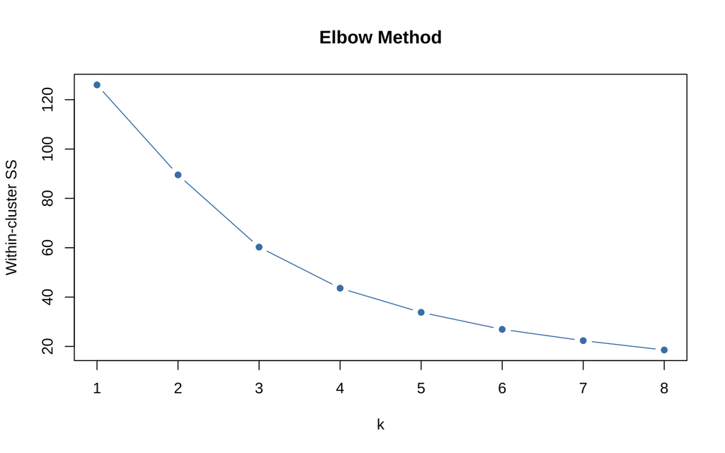

```r
X_scaled <- scale(X_2024)
set.seed(42)

# Elbow method
wss <- sapply(1:8, function(k) kmeans(X_scaled, k, nstart=25)$tot.withinss)
plot(1:8, wss, type="b", pch=16, col="steelblue",
     xlab="k", ylab="Within-cluster SS", main="Elbow Method")
```

```r
# 最終模型
km <- kmeans(X_scaled, centers=4, nstart=25)
df_2024$cluster <- factor(km$cluster)

cat("各群縣市數：\n"); print(table(df_2024$cluster))
```

```
## 各群縣市數：
```

```
##
## 1 2 3 4
## 2 8 7 2
```

```r
cat("\n各群平均薪資：\n"); print(tapply(df_2024$wage, df_2024$cluster, mean))
```

```
##
## 各群平均薪資：
```

```
##        1        2        3        4
## 6.825000 4.500000 4.178571 5.366650
```

```r
# 列出各群縣市名單（讓後續群命名有依據）
cat("\n各群縣市名單：\n")
```

```
##
## 各群縣市名單：
```

```r
print(tapply(df_2024$county, df_2024$cluster, function(x) paste(sort(x), collapse="、")))
```

```
##                                                                1
##                                                 "新竹市、新竹縣"
##                                                                2
## "嘉義市、彰化縣、新北市、桃園市、臺中市、臺南市、苗栗縣、高雄市"
##                                                                3
##         "南投縣、嘉義縣、宜蘭縣、屏東縣、臺東縣、花蓮縣、雲林縣"
##                                                                4
##                                                 "基隆市、臺北市"
```

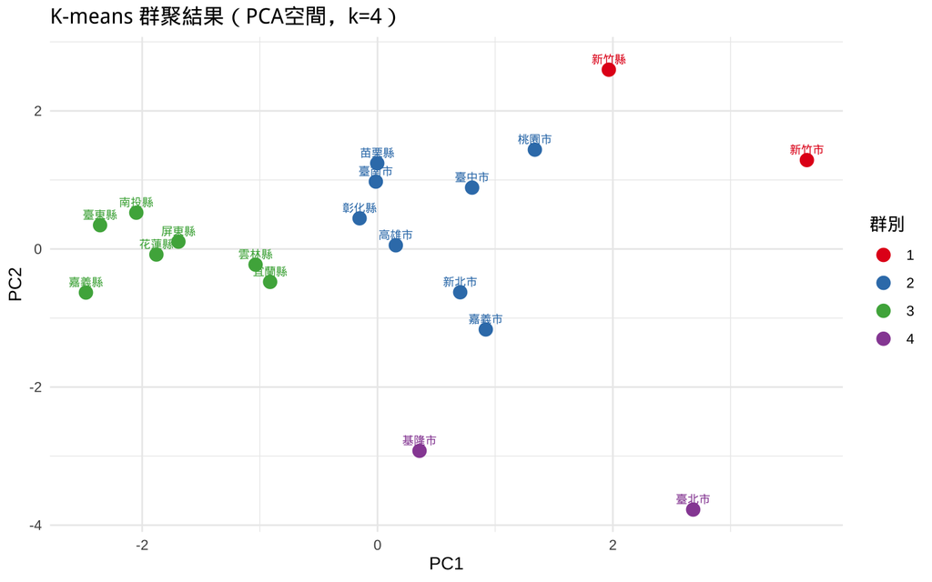

```r
scores$cluster <- df_2024$cluster

ggplot(scores, aes(x=PC1, y=PC2, color=cluster, label=county)) +
  geom_point(size=3.5) +
  geom_text(nudge_y=0.15, size=2.5, check_overlap=TRUE) +
  scale_color_brewer(palette="Set1") +
  labs(title="K-means 群聚結果（PCA空間，k=4）", color="群別") +
  theme_minimal()
```

### 4.2 階層式群聚

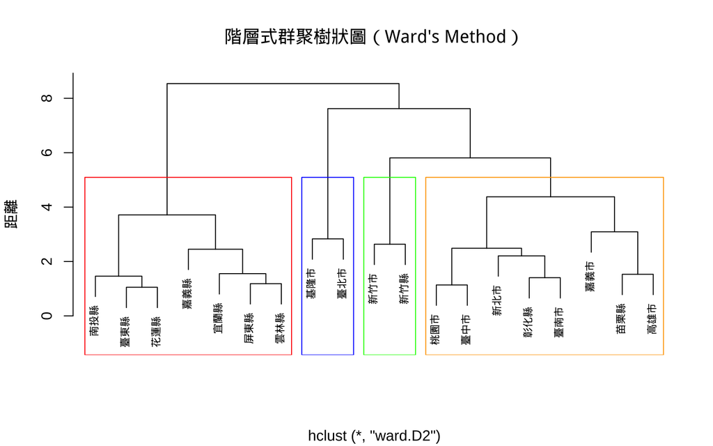

```r
dist_mat <- dist(X_scaled, method="euclidean")
hc       <- hclust(dist_mat, method="ward.D2")

plot(hc, labels=df_2024$county,
     main="階層式群聚樹狀圖（Ward's Method）",
     xlab="", ylab="距離", cex=0.7)
rect.hclust(hc, k=4, border=c("red","blue","green","orange"))
```

## 五、迴歸模型比較

```r
predictors <- c("unemp_rate","lfpr","college_pct","aging_idx","log_density","industry_pct")

# 以時間切割：2019–2023 訓練，2024 測試，避免同縣市跨年資料洩漏
df_model   <- df[, c("log_wage", "year", predictors)] |> na.omit()
train_data <- df_model[df_model$year < 2024, predictors |> c("log_wage")] |> (\(d) d[, c("log_wage", predictors)])()
test_data  <- df_model[df_model$year == 2024, c("log_wage", predictors)]

cat("Train size:", nrow(train_data), "| Test size:", nrow(test_data), "\n")
```

```
## Train size: 95 | Test size: 19
```

```r
X_train <- as.matrix(train_data[, predictors])
y_train <- train_data$log_wage
X_test  <- as.matrix(test_data[, predictors])
y_test  <- test_data$log_wage

rmse <- function(a, p) sqrt(mean((a-p)^2))
r2   <- function(a, p) 1 - sum((a-p)^2)/sum((a-mean(a))^2)
results <- list()
```

```r
ols <- lm(log_wage ~ ., data=train_data)
pred_ols <- predict(ols, test_data)
results[["OLS"]] <- c(RMSE=rmse(y_test,pred_ols), R2=r2(y_test,pred_ols))
summary(ols)
```

```
##
## Call:
## lm(formula = log_wage ~ ., data = train_data)
##
## Residuals:
##       Min        1Q    Median        3Q       Max
## -0.206758 -0.064053  0.003669  0.071949  0.254257
##
## Coefficients:
##                Estimate Std. Error t value Pr(>|t|)
## (Intercept)   0.6798168  0.5758525   1.181  0.24097
## unemp_rate   -0.0293055  0.0696055  -0.421  0.67477
## lfpr          0.0038801  0.0075137   0.516  0.60687
## college_pct   0.0137207  0.0019088   7.188 2.04e-10 ***
## aging_idx     0.0001234  0.0003962   0.311  0.75625
## log_density  -0.0421564  0.0144521  -2.917  0.00448 **
## industry_pct  0.0066153  0.0015834   4.178 6.91e-05 ***
## ---
## Signif. codes:  0 '***' 0.001 '**' 0.01 '*' 0.05 '.' 0.1 ' ' 1
##
## Residual standard error: 0.1025 on 88 degrees of freedom
## Multiple R-squared:  0.6247, Adjusted R-squared:  0.5991
## F-statistic: 24.41 on 6 and 88 DF,  p-value: < 2.2e-16
```

```r
cat("\nOLS Test RMSE:", round(results[["OLS"]]["RMSE"],4),
    "| Test R²:", round(results[["OLS"]]["R2"],4), "\n")
```

```
##
## OLS Test RMSE: 0.1125 | Test R²: 0.5548
```

> **注意：`log_density` 係數為負**，看似矛盾（台北密度高薪資也高），但這是控制 `college_pct` 等變數後的**偏效果**：在教育程度相近的條件下，人口越密集的縣市薪資反而稍低，可能反映都市內部薪資分配不均（高薪少數拉高平均，但中位數未必高）或高生活成本抵消薪資優勢。需搭配實質資料解讀，不宜單獨詮釋。

```r
# Ridge
cv_ridge  <- cv.glmnet(X_train, y_train, alpha=0, nfolds=5)
ridge_mod <- glmnet(X_train, y_train, alpha=0, lambda=cv_ridge$lambda.min)
pred_ridge <- predict(ridge_mod, X_test)[,1]
results[["Ridge"]] <- c(RMSE=rmse(y_test,pred_ridge), R2=r2(y_test,pred_ridge))

# Lasso
cv_lasso  <- cv.glmnet(X_train, y_train, alpha=1, nfolds=5)
lasso_mod <- glmnet(X_train, y_train, alpha=1, lambda=cv_lasso$lambda.min)
pred_lasso <- predict(lasso_mod, X_test)[,1]
results[["Lasso"]] <- c(RMSE=rmse(y_test,pred_lasso), R2=r2(y_test,pred_lasso))
cat("Lasso 保留係數：\n"); print(coef(lasso_mod))
```

```
## Lasso 保留係數：
```

```
## 7 x 1 sparse Matrix of class "dgCMatrix"
##                        s0
## (Intercept)   0.876835342
## unemp_rate   -0.032699341
## lfpr          0.001538444
## college_pct   0.011946735
## aging_idx     .
## log_density  -0.028801290
## industry_pct  0.005836864
```

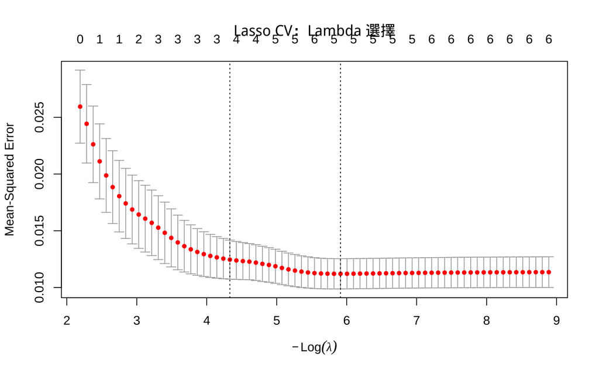

```r
# Elastic Net
cv_enet  <- cv.glmnet(X_train, y_train, alpha=0.5, nfolds=5)
enet_mod <- glmnet(X_train, y_train, alpha=0.5, lambda=cv_enet$lambda.min)
pred_enet <- predict(enet_mod, X_test)[,1]
results[["ElasticNet"]] <- c(RMSE=rmse(y_test,pred_enet), R2=r2(y_test,pred_enet))

plot(cv_lasso, main="Lasso CV：Lambda 選擇")
```

```r
# PCR
pcr_mod  <- pcr(log_wage ~ ., data=train_data, scale=TRUE, validation="CV")
ncomp    <- which.min(RMSEP(pcr_mod)$val[1,,]) - 1
pred_pcr <- predict(pcr_mod, test_data, ncomp=ncomp)[,,1]
results[["PCR"]] <- c(RMSE=rmse(y_test,pred_pcr), R2=r2(y_test,pred_pcr))
cat("PCR 最佳主成分數：", ncomp, "\n")
```

```
## PCR 最佳主成分數： 6
```

```r
# PLS
pls_mod  <- plsr(log_wage ~ ., data=train_data, scale=TRUE, validation="CV")
ncomp_p  <- which.min(RMSEP(pls_mod)$val[1,,]) - 1
pred_pls <- predict(pls_mod, test_data, ncomp=ncomp_p)[,,1]
results[["PLS"]] <- c(RMSE=rmse(y_test,pred_pls), R2=r2(y_test,pred_pls))
```

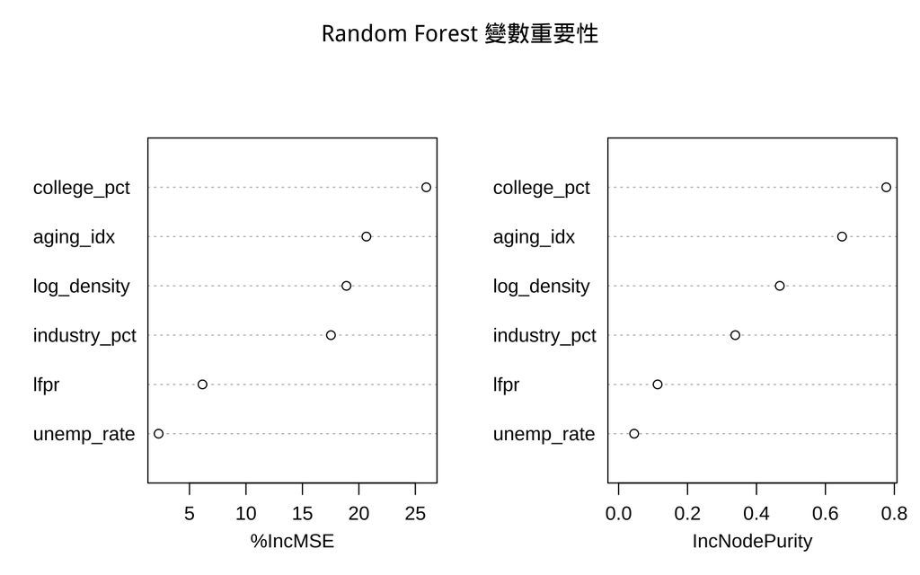

```r
# Random Forest
set.seed(42)
rf_mod  <- randomForest(log_wage ~ ., data=train_data, ntree=500, importance=TRUE)
pred_rf <- predict(rf_mod, test_data)
results[["RandomForest"]] <- c(RMSE=rmse(y_test,pred_rf), R2=r2(y_test,pred_rf))
varImpPlot(rf_mod, main="Random Forest 變數重要性")
```

```r
# GBM
set.seed(42)
gbm_mod  <- gbm(log_wage ~ ., data=train_data, distribution="gaussian",
                n.trees=500, interaction.depth=3, shrinkage=0.01,
                cv.folds=5, verbose=FALSE)
best_iter <- gbm.perf(gbm_mod, method="cv", plot.it=FALSE)
pred_gbm  <- predict(gbm_mod, test_data, n.trees=best_iter)
results[["GBM"]] <- c(RMSE=rmse(y_test,pred_gbm), R2=r2(y_test,pred_gbm))

# SVR（明確儲存 scale 參數，避免反標準化混淆）
train_center <- colMeans(train_data)
train_scale  <- apply(train_data, 2, sd)
tr_sc <- as.data.frame(scale(train_data, center=train_center, scale=train_scale))
te_sc <- as.data.frame(scale(test_data,  center=train_center, scale=train_scale))
svr_mod  <- svm(log_wage ~ ., data=tr_sc, kernel="radial", cost=10, epsilon=0.1)
pred_svr <- predict(svr_mod, te_sc) * train_scale["log_wage"] + train_center["log_wage"]
results[["SVR"]] <- c(RMSE=rmse(y_test,pred_svr), R2=r2(y_test,pred_svr))
```

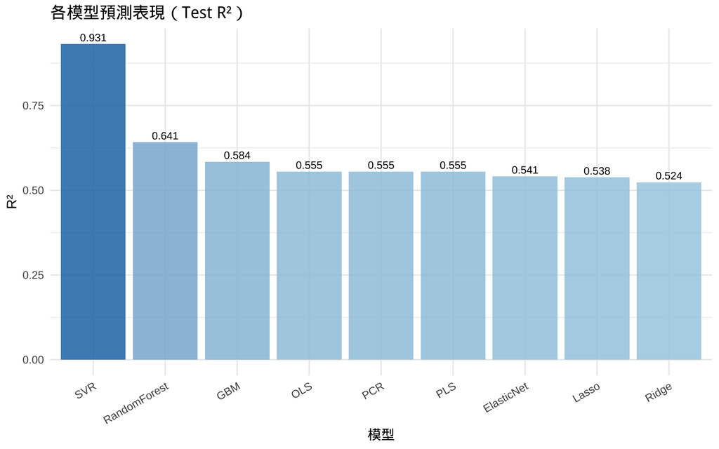

```r
comp_df <- as.data.frame(do.call(rbind, results))
comp_df$Model <- rownames(comp_df)
comp_df <- comp_df %>% arrange(RMSE)

ggplot(comp_df, aes(x=reorder(Model,-R2), y=R2, fill=R2)) +
  geom_col(alpha=0.85) +
  geom_text(aes(label=round(R2,3)), vjust=-0.4, size=3) +
  scale_fill_gradient(low="#a6cee3", high="#1f78b4") +
  labs(title="各模型預測表現（Test R²）", x="模型", y="R²") +
  theme_minimal() +
  theme(legend.position="none", axis.text.x=element_text(angle=30,hjust=1))
```

## 六、分類分析：預測高薪／低薪縣市

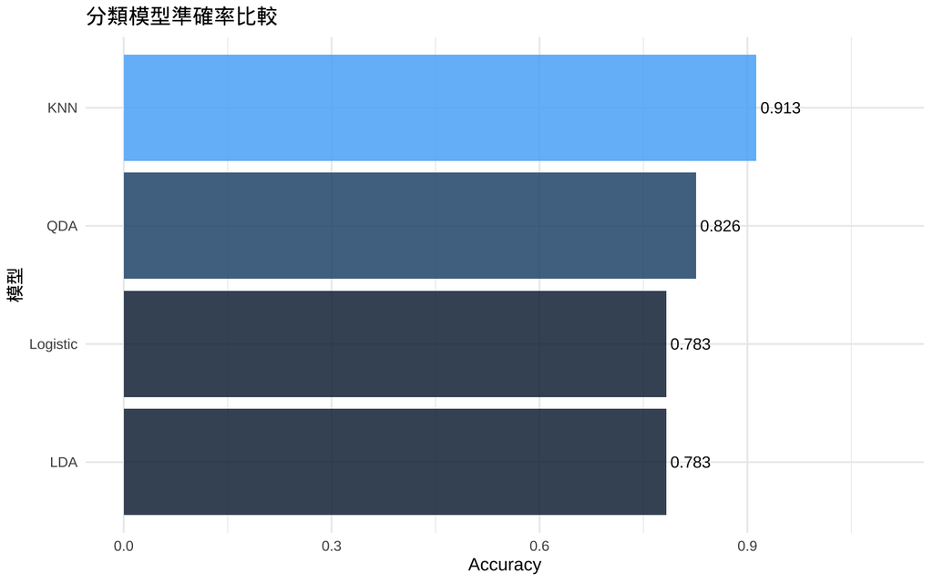

```r
select <- dplyr::select
df_cls <- df %>%
  select(all_of(c("high_wage", predictors))) %>%
  na.omit() %>%
  mutate(high_wage = factor(high_wage, labels=c("低薪","高薪")))

set.seed(42)
tr_idx <- sample(nrow(df_cls), 0.8*nrow(df_cls))
tr_cls <- df_cls[tr_idx,]; te_cls <- df_cls[-tr_idx,]

acc <- function(p,a) mean(p==a)
cls_res <- list()

# Logistic
logit <- glm(high_wage ~ ., data=tr_cls, family=binomial)
p_log <- factor(ifelse(predict(logit,te_cls,type="response")>0.5,"高薪","低薪"), levels=c("低薪","高薪"))
cls_res[["Logistic"]] <- acc(p_log, te_cls$high_wage)

# LDA
lda_m <- lda(high_wage ~ ., data=tr_cls)
cls_res[["LDA"]] <- acc(predict(lda_m, te_cls)$class, te_cls$high_wage)

# QDA
qda_m <- qda(high_wage ~ ., data=tr_cls)
cls_res[["QDA"]] <- acc(predict(qda_m, te_cls)$class, te_cls$high_wage)

# KNN（最佳 k）
X_tr <- scale(tr_cls[,predictors]); X_te <- scale(te_cls[,predictors], center=attr(X_tr,"scaled:center"), scale=attr(X_tr,"scaled:scale"))
best_k <- which.max(sapply(1:15, function(k) acc(knn(X_tr,X_te,tr_cls$high_wage,k=k), te_cls$high_wage)))
cls_res[["KNN"]] <- acc(knn(X_tr, X_te, tr_cls$high_wage, k=best_k), te_cls$high_wage)

data.frame(Model=names(cls_res), Accuracy=round(unlist(cls_res),3)) %>%
  arrange(desc(Accuracy)) %>%
  ggplot(aes(x=reorder(Model,Accuracy), y=Accuracy, fill=Accuracy)) +
  geom_col(alpha=0.85) +
  geom_text(aes(label=Accuracy), hjust=-0.1, size=3.5) +
  coord_flip() + scale_y_continuous(limits=c(0,1.1)) +
  labs(title="分類模型準確率比較", x="模型", y="Accuracy") +
  theme_minimal() + theme(legend.position="none")
```

## 七、重抽樣方法：Bootstrap + 交叉驗證

```r
set.seed(42)

kfold <- function(data, k) {
  folds <- sample(rep(1:k, length.out=nrow(data)))
  mean(sapply(1:k, function(i) {
    m <- lm(log_wage~., data=data[folds!=i,])
    sqrt(mean((data$log_wage[folds==i] - predict(m, data[folds==i,]))^2))
  }))
}

df_m <- df[, c("log_wage", predictors)] |> na.omit()
cv5  <- kfold(df_m, 5)
cv10 <- kfold(df_m, 10)

# LOO
loo_e <- sapply(1:nrow(df_m), function(i) {
  m <- lm(log_wage~., data=df_m[-i,])
  df_m$log_wage[i] - predict(m, df_m[i,])
})
loo_rmse <- sqrt(mean(loo_e^2))

cat("5-fold CV RMSE:", round(cv5,4), "\n10-fold CV RMSE:", round(cv10,4), "\nLOO-CV RMSE:", round(loo_rmse,4), "\n")
```

```
## 5-fold CV RMSE: 0.1114
## 10-fold CV RMSE: 0.1041
## LOO-CV RMSE: 0.1073
```

```r
set.seed(42)
B <- 1000

boot_coef <- replicate(B, {
  idx <- sample(nrow(df_m), replace=TRUE)
  coef(lm(log_wage~., data=df_m[idx,]))
})

ci <- apply(boot_coef, 1, quantile, probs=c(0.025,0.975))
cat("Bootstrap 95% CI（OLS 係數）：\n")
```

```
## Bootstrap 95% CI（OLS 係數）：
```

```r
print(round(ci, 4))
```

```
##       (Intercept) unemp_rate    lfpr college_pct aging_idx log_density
## 2.5%      -0.2302    -0.1896 -0.0103      0.0102    -6e-04     -0.0679
## 97.5%      1.9212     0.0678  0.0172      0.0172     9e-04     -0.0135
##       industry_pct
## 2.5%        0.0040
## 97.5%       0.0092
```

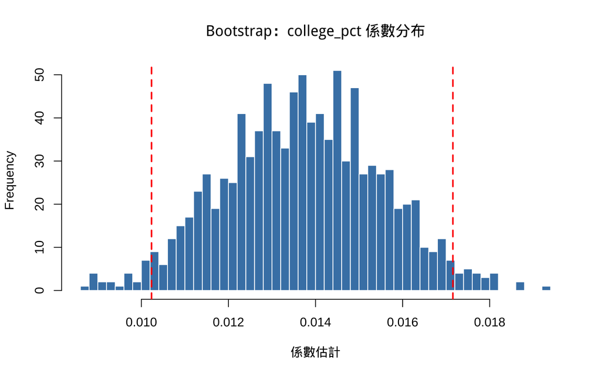

```r
hist(boot_coef["college_pct",], breaks=40, col="steelblue", border="white",
     main="Bootstrap：college_pct 係數分布",
     xlab="係數估計")
abline(v=ci[,"college_pct"], col="red", lty=2, lwd=2)
```